# Homework #4

Andres Gonzalez

2/27/2022

## Cars and mileage

#### Due: 2/27/2022 before 11:59pm. Submit in Canvas (file upload).

In this homework we will use the `mpg` data set, you can access the data by loading the package `ggplot2` into your R session by executing the command `library(ggplot2)`. The `mpg` data includes information about fuel economy of popular car models for the years 1999 and 2008 as collected by the US Environmental Protection Agency.

Most exercises are from the ggplot2 book section 2.2.1. You might find it helpful for working on the homework to read through this section.

1. Download the RMarkdown file with these homework instructions to use as a template for your work. Make sure to replace “Your Name” in the YAML with your name.
2. List five functions that you could use to get more information about the mpg dataset.
- `summary`: print some summary statistics for each variable
- `View`: to see the whole data set in a nice spread-sheet like fashion
- `str` : get info on the structure of the `mpg` object
- `dplyr::glimps`: similar to `str` but much tidier
- `class`: to get its class
3. Using the `ggplot2` package create a scatterplot of `hwy` and `cty` and describe the relationship. Why are there so few points visible? Use a geom that helps reduce the amount of overplotting in the scatterplot. (Try `?geom_jitter`)

   The higher that ‘hwy’ numbers, ‘cty’ numbers also go up as well.

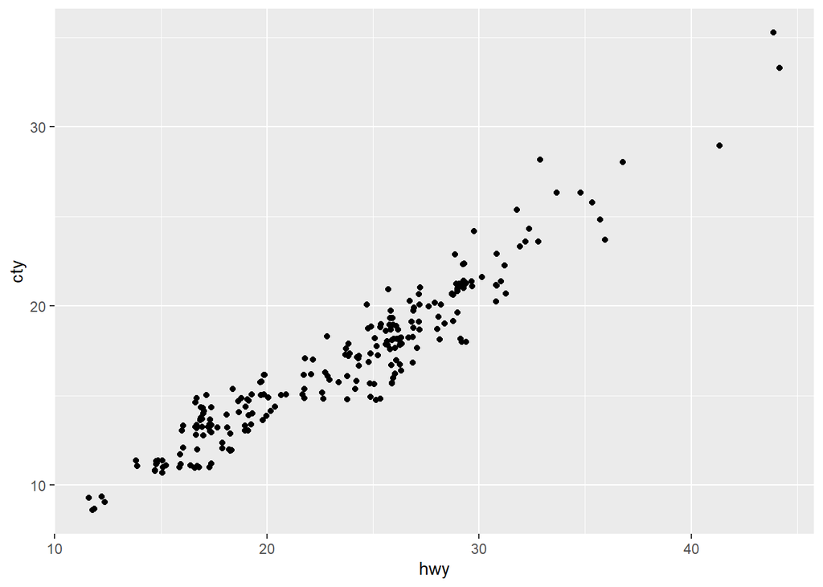

```r
ggplot(mpg, aes(hwy, cty)) + geom_jitter()
```

4. Apart from the US, most countries use fuel consumption (fuel consumed over fixed distance) rather than fuel economy (distance traveled with fixed amount of fuel). How could you convert `cty` and `hwy` into the European standard of liter/100 km? Introduce corresponding variables into the `mpg` data.

   We could use `apply` to convert the columns

   ```r
   apply(mpg[, c("cty", "hwy")], 2, mpgTol100km) %>%
     head()
   ```

   ```
   ##           cty      hwy
   ## [1,] 13.06748 8.110848
   ## [2,] 11.20069 8.110848
   ## [3,] 11.76073 7.587567
   ## [4,] 11.20069 7.840486
   ## [5,] 14.70091 9.046715
   ## [6,] 13.06748 9.046715
   ```

Another possibility is to use the `dplyr` functions `transmute` or `mutate`

```r
mpg %>%
  transmute("cty_l100km" = mpgTol100km(cty),
            "hwy_l100km" = mpgTol100km(hwy))
```

```
## # A tibble: 234 × 2
##    cty_l100km hwy_l100km
##         <dbl>      <dbl>
##  1       13.1       8.11
##  2       11.2       8.11
##  3       11.8       7.59
##  4       11.2       7.84
##  5       14.7       9.05
##  6       13.1       9.05
##  7       13.1       8.71
##  8       13.1       9.05
##  9       14.7       9.41
## 10       11.8       8.40
## # … with 224 more rows
```

5. Are cars in 2008 more fuel efficient than cars in 1999? Expand on your answer in (3) for a visual approach to this question. Note: you are not asked to find numeric answers. Instead, interpret plots.

   They are about the same. there is a lot of overlap in the same areas. Some of the cars from 1999 get more MPG than their 2008 counterparts.

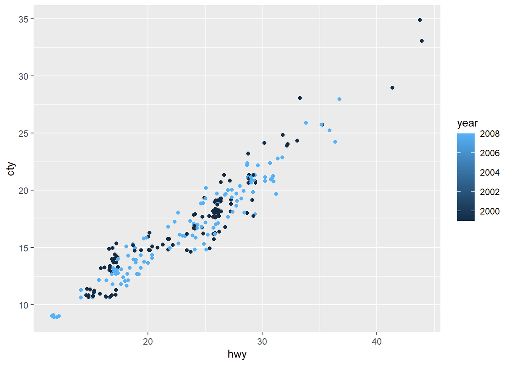

```r
ggplot(aes(x=hwy, y =cty, color = year), data = subset(mpg, year == 2008 | year == 1999), select = c(hwy, cty)) + geom_jitter()
```

6. Use the `ggplot2` package to create side-by-side boxplots of `cty` by `class`. Describe the relationship in 2-3 sentences. Change the label for the y-axis to ‘city miles per gallon’ (see `?ylab`).

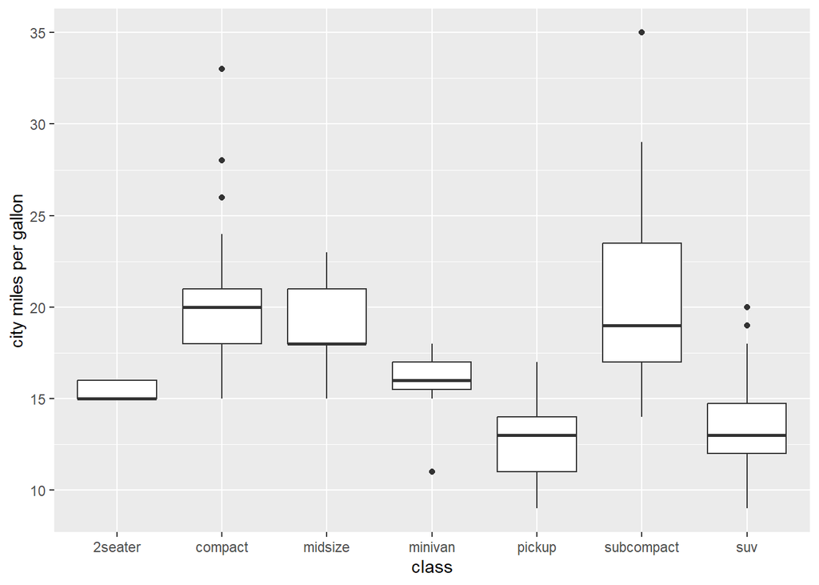

```r
ggplot(aes(x = class, y = cty),data=mpg) + geom_boxplot() + scale_y_continuous(name="city miles per gallon")
```

The bigger cars get less MPG in the city. The more smaller to compact cars are more efficient.

Note: your submission is supposed to be fully reproducible, i.e. the TA and I will ‘knit’ your submission in RStudio.

For the submission: submit your solution in an **R Markdown file** and (just for insurance) submit the **corresponding html (or Word)** file with it.